# Classificaton of Wildfire Impact, aka Canopy Mortality

Paul Bentley

2016-04-29

# 1 Introduction

## 1.1 Aim

Undertake exploratory data analysis of field data collected during June 2015 field campaign.

## 1.2 Scope

- Go through the work already undertaken to select what ideas kind of worked.
- Rather than a manual classification try clustering techniques.
1. shortlist field measurements which relate to either structural measurements
2. shortlist metrics which relate to ecological fire responce, and use this generate site classification for site mortality

# 2 Quality Assurance

## 2.1 Field Survey

ISSUE - misallignment with field plot and lidar data

comments: - looking through the LIDAR heights and comparing to the field notes discrepencies between field obsered heights and LIDAR heights exist. Classification between field heights and LIDAR heights is introducing a source of error. Use of absolute values from field, especially higher up teh canopy to be used with caution. Ratios possible, but then confusion can occur. - after runnign QAQC checks using the veg height to truth the locations, several needed to be moved slightly due to falling in wrong lidar cell (i.e wrong side of cell border), being on a boundary (just confusing). Other sources of error may include measurement error in feld (due to terrain), and trees falling down between 2012 and 2015.

```r
# import adata
setwd("~/Projects/2015_LIDAR_Kinglake/20_Data_Analysis/00_field_data_analysis")
indata <- read.csv("R_field_V2_April2016.csv")
indata <- subset(indata, Site < 90)

require(raster)
setwd("~/Projects/2015_LIDAR_Kinglake/10_fusion_output/fusion_2008/Metrics_20METERS")
xlist <- list.files()
xlist <- xlist[grep("elev_P99_5plus_20METERS.asc",xlist)]

ras08 <- stack(xlist)

field <- extract(ras08, indata[2:3])
field <-as.data.frame(field)
field$site <- indata$Site
field$x<-indata$x
field$y<-indata$y
indata[is.na(indata)]<- 0
```

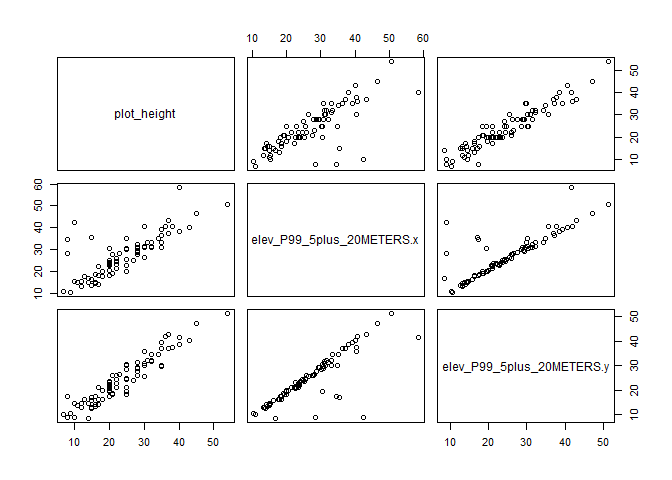

```r
field$plot_height <- apply(indata[,c("lc_u","dc_u","ms_u","us_u")],1,max)

setwd("~/Projects/2015_LIDAR_Kinglake/10_fusion_output/fusion_2012/Metrics_20METERS")
xlist <- list.files()
xlist <- xlist[grep("elev_P99_5plus_20METERS.asc",xlist)]

ras12 <- stack(xlist)
field1 <- extract(ras12, indata[2:3])
field1 <-as.data.frame(field1)
field1$site <- indata$Site
field1$x<-indata$x
field1$y<-indata$y
indata[is.na(indata)]<- 0
field1$plot_height <- apply(indata[,c("lc_u","dc_u","ms_u","us_u")],1,max)

field2 <- merge(field, field1, by=c("x","y","site","plot_height"))

field2$diff <- abs(field2$elev_P99_5plus_20METERS.y-field2$plot_height)

pairs(~plot_height + elev_P99_5plus_20METERS.x +elev_P99_5plus_20METERS.y, data=field2)
```

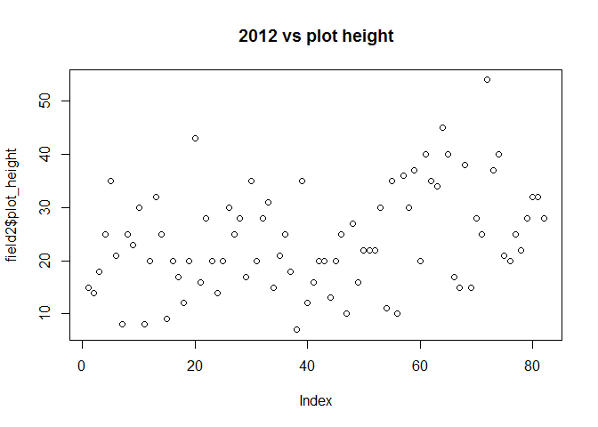

```r
plot(field2$plot_height,field2$canopy_20METERS_average_height.y, main= "2012 vs plot height")
```

# 3 Rule Based (Manual) Classification of Canopy Mortality

The purpose of this stage is to classify field plots into stages of canopy mortality to use in a classification model to map mortality across the study area.

## 3.1 Approaches to Mapping Mortality

Mortality can be conceptualised in a number of ways. Ulitmately here it is about quantifying if a tree has died due to fire. This includes a numbe rof assumptions and complications: - the tree died due to fire, if indeed dead. - a tree may be alive, even if barely. This raises the question of hwo do you measure death, and what is a dead tree. - how to best classify sites? i have predominantly beenusing rule based approaches and these have difficulty in forest with partial canopy death, and canopy recovery / removal. Extremes classify well, however the partial layer does not. - some classification systems include a life-cycle approach to trees in the landscape, and that trees have several lifestages. WHile fire may not kill a tree outright, it may shift the tree into a different life stage (accelerate…). So to LIDAR a dead tree and partially dead tree may look the same. Which is the problem i have found with my preexisting thinking. - LIDAR can only see so much. i need to be able to relate field observations to something which LIDAR can measure at a broad scale. - How to describe change between LIDAR events? what are the most appropriate metrics to undertake this? - When i use my composite metrics how do i integrate them into a model? Should i just be using some classification approach for individual layers, not the multilayer inputs required for RF? - The field classification needs to be simple yet comprehensive to enable wider adoption.

## 3.2 Conceptual Model

What are the lifestages and cycles trees in eucalypt forests go through in the study area? predominantly resprouters, their responce post fire influenced by fire intensity and stage of life prefire, plus any post fire responce to weather, insect and fungal attack, etc.

To class mortality imlies a rating scale, say from 1 to 5, or however many categories are meaningful. This in turn depends on the classificaion, and being able to meaningfully interpret the classification which occurs. From previous musings i can distinguish where there is no canopy change or complete removal of trees. Where i have struggled is the mixed vegetation responce, where partial canopy death and variable recovery occurs. Driving the area there is clearly a topographical relationship, which is driven by inderlying vegetation communities responding to moisture and nutrient distributions in the landscape. Can i capture this in the classification? What am i trying to say - Low, Medium, High mortality? Category A is 10-20% death, B is 30-50% death? (this has been done in non-resprouting forests). This would be simple from field plots. Problem with a clustering classification, while the results fit the map i would expect i cannot explain the story clearly. That is why linking the clustering to a degree of site exposure, which in turn is a measure of mortality is a possible solution. So rather than quantify and train the dataset using the number of dead trees, i want to use measures of site impact, tree damage, death, responce effort, to describe the site canopy recovery. Perhaps into poor, removal, good, strong, recovery. discuss in terms of rate and strength of recovery?

This is what i have been working through using the rule based classification, which is based on my fuling of responce. My rulings based on dead tree, and post fire morphology. Really i am mapping post fire morphological responce 3 years post fire. What is the forest doing? where is the recovery happening at a physiological level and individual level in groupd of plants? What is the average response, can i capture this in a mortality metric, and can i model this using the LDIAR data?

i am really struggling to tell if the trees are alive or dead because of the similarity between partially recovery and dead trees to lidar at the scale i am measuring. Meaning that structurally they appear similar. The intensity readings would be similar unless excessive regrowth. but then again maybe my classification is amiss…

## 3.3 Measures of Mortality

My current mortality classifiation for RF. This uses the growth stage data to classify sites in the forest into a single category. First step to post process field data slightly to calculate percentages of tree growth and stage.

```r
setwd("~/Projects/2015_LIDAR_Kinglake/20_Data_Analysis/00_field_data_analysis")
indata <- read.csv("R_field_V2_April2016.csv")
indata <- subset(indata, Site < 90)

#total trees = alive and dead standing, and logs.
indata$numtrees <- indata$tree_log + indata$tree_dead + indata$tree_alive
indata$tree_standing <- (indata$tree_dead + indata$tree_alive)

#calculate % of live canopy standing
indata$canopy_live<-(indata$pfmbs_3+indata$pfmbs_4A)/indata$numtrees
indata$canopy_live[is.na(indata$canopy_live)==T]<-0

#calculate % of unburnt canopy
indata$canopy_unburnt <-(indata$pfmbs_3)/indata$numtrees
indata$canopy_unburnt[is.na(indata$canopy_unburnt)==T]<-0

#calc % of canopy and trunk eicormic
indata$fullepicormic<-(indata$pfmbs_4A)/indata$numtrees
indata$fullepicormic[is.na(indata$fullepicormic)==T]<-0

#calc % of trunk epicormic
indata$epicormic<-(indata$pfmbs_4B)/indata$numtrees
indata$epicormic[is.na(indata$epicormic)==T]<-0
```

### 3.3.1 Tree Mortality Ratio

Metric calculates number of dead trees per site, and consideres coppice, stags and logs.

```r
indata$mort<-(indata$pfmbs_5A+indata$pfmbs_4C+indata$tree_log)/indata$numtrees
indata$mort[is.na(indata$mort)] <- 0
```

### 3.3.2 Live Canopy Depth

Metric calculates the depth of dead crown based on canopy height. In the field it was observed at several sites that trees were alive however the upper portion of hte canopy was destroyed (i assume cambila failure above a temperature threshold, possibly the diameter of the branches). So while hte trees may survive the upper portion of the canopy is dead, as in no epicormic regrowth.

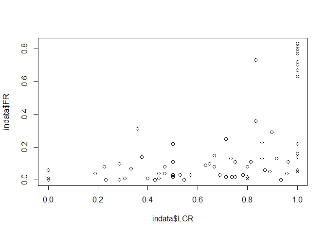

```r
#live canopy depth
indata$canheight <- pmax(indata$dc_u,indata$lc_u,na.rm=T)
indata$candepth <- indata$canheight - pmin(indata$dc_l,indata$lc_l,na.rm=T)
indata$livezone <- indata$lc_u-indata$lc_l
indata$LCR<- indata$livezone/indata$candepth
indata$LCR[is.na(indata$LCR)] <- 0

#foliage ratio
indata$FR <- (indata$fcov_os)/100
indata$FR[is.na(indata$FR)] <- 0

plot(indata$LCR, indata$FR)
```

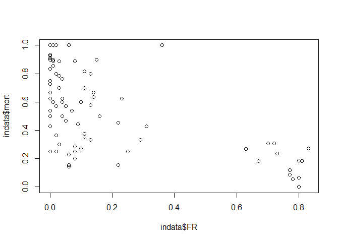

```r
plot(indata$FR,indata$mort)
```

### 3.3.3 Combo

By combining the Tree mort ratio and canpopy mort depth the intention is to create a composite metric which can classify field plots using a rule based approach to reflect the degree of canopy depth, and the ability of canopy to recover using the mature pre-fire tree.

Again, this is rule based and does not consider variables such as vegetation type, landscape positioning, etc. It is an independant test which can then be linked to vegetation type later on to see if there is a relationship between mortality, ecological severity and vegetation type

## 3.4 Severity Classes

Classify sites based on their degree of canopy mortality using rules. code names below are hangovers from earlier attempts.

My original classification used the following logic: - classify sites based on percent of live / dead trees - classify sites based on precence / abcence of fire affected morphology -

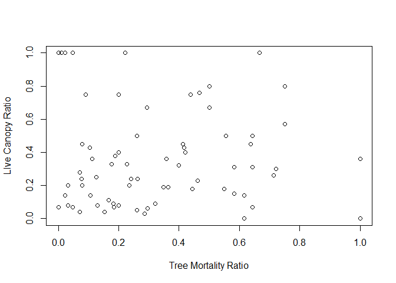

```r
#mortality metrics site based
indata$numtrees<-rowSums(indata[,33:37]) #basal sweep count

indata$percliving<-(indata$pfmbs_3+indata$pfmbs_4A)/indata$numtrees

indata$percliving[is.na(indata$percliving)==T]<-0

indata$unburnt<-(indata$pfmbs_3)/indata$numtrees
indata$unburnt[is.na(indata$unburnt)==T]<-0

indata$fullepicormic<-(indata$pfmbs_4A)/indata$numtrees
indata$fullepicormic[is.na(indata$fullepicormic)==T]<-0

indata$epicormic<-(indata$pfmbs_4B)/indata$numtrees
indata$epicormic[is.na(indata$epicormic)==T]<-0

indata$coppice<-(indata$pfmbs_4C)/indata$numtrees
indata$coppice[is.na(indata$coppice)==T]<-0

indata$dead<-(indata$pfmbs_5A+indata$pfmbs_4C)/indata$numtrees
indata$mort<-indata$dead
indata$mort[is.na(indata$mort)] <- 1

indata$mort<-ifelse(indata$csm_scenario==3, "0",indata$mort)
indata$mort<-ifelse(indata$csm_scenario==6, "1",indata$mort)

indata$mort[is.na(indata$mort)] <- 1
indata$mort <- as.numeric(indata$mort)

indata$dc_height<-ifelse(indata$csm_scenario==3, "1", indata$dc_height)
indata$dc_height<-ifelse(indata$csm_scenario==6, "0", indata$dc_height)

plotdat<-subset(indata, indata$percliving<0.8 & indata$dead!=1)
plot(indata$mort, indata$dc_height, xlab = "Tree Mortality Ratio", ylab="LIve Canopy Ratio")
```

```r
#Model 1A (CMM1A) : prescence / absence where 3 >4A >4B >4C >5A
indata$CMM1A<-ifelse(indata$numtrees==0, "E", "E")
indata$CMM1A<-ifelse(indata$pfmpa_5A>0, "D", indata$CMM1A)
indata$CMM1A<-ifelse(indata$pfmpa_4C>0, "D", indata$CMM1A)
indata$CMM1A<-ifelse(indata$pfmpa_4B>0, "C", indata$CMM1A)
indata$CMM1A<-ifelse(indata$pfmpa_4A>0, "B", indata$CMM1A)
indata$CMM1A<-ifelse(indata$pfmpa_3>0, "A", indata$CMM1A)
indata$CMM1A<-ifelse(indata$csm_scenario==3, "A", indata$CMM1A)
indata$CMM1A<-ifelse(indata$csm_scenario==6, "E", indata$CMM1A)

#Model 1B (CMM1B) : prescence / absence where 3 + 4A >4B >4C >5A
indata$CMM1B<-ifelse(indata$numtrees==0, "E", "E")
indata$CMM1B<-ifelse(indata$pfmpa_5A>0, "D", indata$CMM1B)
indata$CMM1B<-ifelse(indata$pfmpa_4C>0, "D", indata$CMM1B)
indata$CMM1B<-ifelse(indata$pfmpa_4B>0, "C", indata$CMM1B)
indata$CMM1B<-ifelse(indata$pfmpa_4A>0, "AB", indata$CMM1B)
indata$CMM1B<-ifelse(indata$pfmpa_3>0, "AB", indata$CMM1B)
indata$CMM1B<-ifelse(indata$csm_scenario==3, "AB", indata$CMM1B)
indata$CMM1B<-ifelse(indata$csm_scenario==6, "E", indata$CMM1B)

#MOdel 1C (CMM1C) : dominance at site where % 3 >4A >4B >4C >5A
indata$CMM1C<-ifelse(indata$pfmbs_5A>0, "D", "D")
indata$CMM1C<-ifelse(indata$epicormic>0 & indata$epicormic>indata$mort, "C", indata$CMM1C)
indata$CMM1C<-ifelse(indata$fullepicormic>0 & indata$fullepicormic>indata$mort, "B", indata$CMM1C)
indata$CMM1C<-ifelse(indata$unburnt>0, "A", indata$CMM1C)
indata$CMM1C<-ifelse(indata$csm_scenario==3, "A", indata$CMM1C)
indata$CMM1C<-ifelse(indata$csm_scenario==6, "E", indata$CMM1C)

##Model_CMM1Z : quazi morphology rule and canopy kill depth
dfc <- subset(indata, select=c("Site",  "pfmbs_3",  "pfmbs_4A"  ,   "pfmbs_4B" ,
                                "pfmbs_4C" , "pfmbs_5A", "pfmbs_5B", "csm_scenario", "dc_height"))

dfc$dommorph <- colnames(dfc[,2:6])[max.col(dfc[,2:6],ties.method="first")]
dfc$dommorph <- ifelse(rowSums(dfc[,2:6])==0, 'pfmbs_6',dfc$dommorph)
dfc$CMM1Z <-ifelse(dfc$csm_scenario==3, "M3", "M3")
dfc$CMM1Z <-ifelse(dfc$csm_scenario==6, "M6", dfc$CMM1Z)
dfc$dommorph <- ifelse(is.na(dfc$dommorph), dfc$CMM1Z, dfc$dommorph)
dfc$CMM1Z <- ifelse(dfc$dommorph=='pfmbs_3', "M3", dfc$CMM1Z)
dfc$CMM1Z <- ifelse(dfc$dommorph=='pfmbs_4A', "M4A", dfc$CMM1Z)
dfc$CMM1Z <- ifelse(dfc$dommorph=='pfmbs_4B' & dfc$dc_height<=0.5, "M4B", dfc$CMM1Z)
dfc$CMM1Z <- ifelse(dfc$dommorph=='pfmbs_4B' & dfc$dc_height>0.5, "M5A", dfc$CMM1Z)
dfc$CMM1Z <- ifelse(dfc$dommorph=='pfmbs_4C', "M5A", dfc$CMM1Z)
dfc$CMM1Z <- ifelse(dfc$dommorph=='pfmbs_5A', "M5A", dfc$CMM1Z)
dfc$CMM1Z <- ifelse(dfc$dommorph=='pfmbs_5B', "M6", dfc$CMM1Z)
dfc$CMM1Z <- ifelse(dfc$dommorph=='pfmbs_6', "M6", dfc$CMM1Z)
```

# 4 Clusting Techniques

## 4.1 Brief Overview

In order to clarify i understand clustering adn what i am doing here i have prepared this brief summary of custering techniques and approaches.

## 4.2 Heirarcical Clustering

A hierarchical clustering method produces a classification in which small clusters of very similar molecules are nested within larger clusters of less closely-related molecules.

Hierarchical agglomerative methods generate a classification in a bottom-up manner, by a series of agglomerations in which small clusters, initially containing individual molecules, are fused together to form progressively larger clusters. Hierarchical agglomerative methods are often characterised by the shape of the clusters they tend to find, as exemplified by the following range:

-single-link - tends to find long, straggly, chained clusters;

-Ward and group-average - tend to find globular clusters;

-complete-link - tends to find extremely compact clusters.

Hierarchical divisive methods generate a classification in a top-down manner, by progressively sub-dividing the single cluster which represents an entire dataset. Monothetic (divisions based on just a single descriptor) hierarchical divisive methods are generally much faster in operation than the corresponding polythetic (divisions based on all descriptors) hierarchical divisive and hierarchical agglomerative methods, but tend to give poor results.

One problem with these methods is how to choose which clusters or partitions to extract from the hierarchy since display of the full hierarchy is not really appropriate for datasets of more than a few hundred compounds.

```r
#HClust
cdat <- indata[,c("LCR","mort")]
cdat<-indata[,c("FR","mort", "canopy_live", "fullepicormic", "epicormic", "canopy_unburnt")]


cdist <- dist(cdat)
hc_cdat <- hclust(cdist,method="ward.D")

dend <- as.dendrogram(hc_cdat)
plot(dend)

#AGNES
agdata <- indata[,c("Site","mort","LCR")  ]
agdata <- indata[,c("Site","FR","mort","LCR")]

require(cluster)
agdist<- dist(agdata[,-1])

agout <- agnes(agdist, method='ward')
#class(agout)
#plot(agout)

xx <- table(cutree(agout,k=4),agdata$Site)
xx <- as.data.frame(xx)
xx <- subset(xx, Freq==1)
xx <- subset(xx, select=-c(Freq))
xx <- merge(xx,agdata,by.x="Var2",by.y="Site")

require(ggplot2)
dfmelt<-reshape2::melt(xx, id.vars = 1:2)
ggplot(dfmelt,aes(x=Var1,y=value,fill=variable))  + geom_boxplot()


hist(as.numeric(xx$Var1))

groups <- cutree(agout,k=5)
table(groups)
counts <- sapply(2:10,function(ncl)table(cutree(agout,ncl)))
names(counts) = 2:10
counts

ag.use = agdata[,-c(1)]
aggregate(ag.use,list(groups),mean)
```

[output not shown]

Keeping the chunk below, there is a story emerging from these three varaibles of tree mortality, depth of crown kill and foilage recovery at each site.

- clust 1: low mortality, canopy all alove and lots of foilage - would indicate low severity, unburnt.
- clust 2: LCR high, meaning epicormic regrowth along stems, low mortality but also low foilage projection, indicating while trees alive to canopy height, slower recovery of canopy projection
- clust 3: FR low, with moderate mort and LCR, same as clust 2 except harder hit
- clust 4: FR low, mort low, but canopy death higher
- clust 5: high death.

it would appear that this is interprable, and using the box plot makes this so. Yes there is going to be a range.

Looking at these results it explains why my rulel based clasification would never work - the rules were too rigid and based on two variable interactions, not three as in the example below. Further i wasnt looking at the range of possible values which may occur, firtly given the noise in these systems and associated distances which may exist.

A point to follow up is Agglomerative Nesting (i.e. Agnes) the way to go??

```r
#AGNES
agdata <- indata[,c("Site","FR","mort","LCR")]

require(cluster)
```

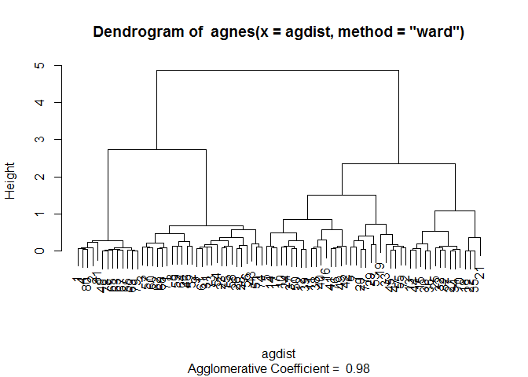

```r
agdist<- dist(agdata[,-1])

agout <- agnes(agdist, method='ward')
plot(agout,which.plots =2)
```

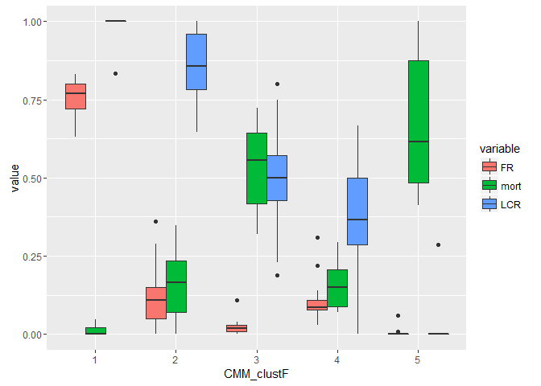

```r
xx <- table(cutree(agout,k=5),agdata$Site) # if i change agdata$Site to something else, i can create a confusion matrix using code in this line
xx <- as.data.frame(xx)
xx <- subset(xx, Freq==1)
xx <- subset(xx, select=-c(Freq))
xx <- plyr::rename(xx, c("Var1" = "CMM_clustF"))

# i like this classification, add to indata
setwd("~/Projects/2015_LIDAR_Kinglake/20_Data_Analysis/00_field_data_analysis")
indata2 <- read.csv("R_field_V2_April2016.csv")
indata2$CMM_clustR <- ifelse(indata2$csm_scenario==3, 1,ifelse(indata2$csm_scenario==6,5,-99999))
indata2 <- merge(indata2, xx, by.x=c("Site"),by.y=c("Var2"),all = TRUE)
indata2$CMM_clustFR <- ifelse(indata2$CMM_clustR>0, indata2$CMM_clustR, indata2$CMM_clustF)


require(ggplot2)
xx <- merge(xx,agdata,by.x="Var2",by.y="Site")
dfmelt<-reshape2::melt(xx, id.vars = 1:2)
ggplot(dfmelt,aes(x=CMM_clustF,y=value,fill=variable))  + geom_boxplot()
```

### 4.2.1 Piggyback: Backward Dendro

This idea for site classification and using lidare comes from Kane et al(2011), and appeared to work quite well. What i need to figure out is how to automatically group the clusters, without using an arbitrary height cutoff across all groups.

Source of idea: Kane, V. R., et al. (2011). “Patch dynamics and the development of structural and spatial heterogeneity in Pacific Northwest forests.” Canadian Journal of Forest Research 41(12): 2276-2291.

## 4.3 Non-Heirarcical Clustering

- relocation methods, such as k-means, assign scompounds to a user-defined number of seed clusters and then iteratively reassign compounds to see if better clusters result. Such methods are prone to reaching local optima rather than a global optimum, and it is generally not possible to determine when or whether the global optimum solution has been reached;
- nearest neighbour methods, such as the Jarvis-Patrick method, assign compounds to the same cluster as some number of their nearest neighbours. User-defined parameters determine how many nearest neighbours need to be considered, and the necessary level of similarity between nearest neighbour lists.

looking at the code and examples below the results are basically useless, as there are not neat clusters to emerge from what i have been looking at; compared with the heirarcical clustering where there does appear at least to be stronger group format and can several field metrics can be used to generate the classification.

Overall i havent been impressed with the results from this. comparing the the heirarcical model above, and for the same variables of mort, FR, and LCR for consistency,

```r
require(useful)
```

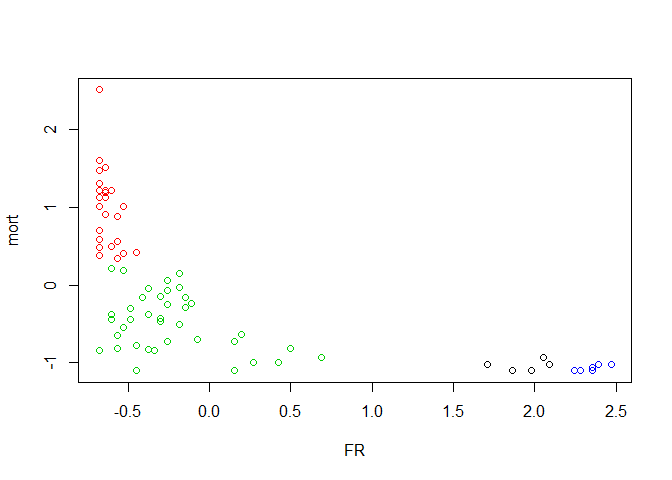

```r
library(car)
library(cluster)
##k-means
kmdata<-indata[,c("Site","LCR","FR","mort")]

kmdata$mort <- as.numeric(kmdata$mort)
kmdata<-na.omit(kmdata)
kmdata <- scale(kmdata[-1])
km<-kmeans(kmdata[,-c(1)], centers=4)

plot(kmdata[,-c(1)], col=km$cluster)
```